# EDA With Temporal Variables

Doug Antibus

2023-12-28

## EDA of ridership over time

This section focuses on using temporal variables to find differences between members and casual riders.

Read in the most recent data file, `bikes_2.csv`, and omit rows containing NA values.

```r
bikes <- read_csv(here("data", "bikes_2.csv")) %>% na.omit()
```

### Data preparation

We start by changing the `dow` (day of week) and `month_abb` (abbreviated month) variables into ordered factors. For `dow` we define the week as starting Monday and ending Sunday, because we want to see weekend days adjacent to each other on plots.

```r
day_order <- c("Mon", "Tue", "Wed", "Thu", "Fri", "Sat", "Sun")
month_order <- c("Jan", "Feb", "Mar", "Apr", "May", "Jun", "Jul", "Aug", "Sep", "Oct", "Nov", "Dec")

bikes <- bikes %>%
  mutate(dow = factor(dow, ordered = TRUE, levels = day_order),
         month_abb = factor(month_abb, ordered = TRUE, levels = month_order))
```

Next, we summarize ride counts by `date` and `member_casual`. In addition to date and rider type, we include other variables such as `month` and `is_weekend` taking these “along for the ride”, as these will be useful in plotting

```r
daily_counts <- bikes %>%
  group_by(date, month, month_abb, dow, is_weekend, member_casual, is_holiday) %>%
  summarize(n = n()) %>%
  arrange(desc(n))
glimpse(daily_counts)
```

```
## Rows: 730
## Columns: 8
## Groups: date, month, month_abb, dow, is_weekend, member_casual [730]
## $ date          <dttm> 2023-08-12, 2023-06-10, 2023-08-01, 2023-08-02, 2023-07…
## $ month         <dbl> 8, 6, 8, 8, 7, 6, 8, 8, 8, 8, 7, 7, 10, 8, 10, 8, 8, 7, …
## $ month_abb     <ord> Aug, Jun, Aug, Aug, Jul, Jun, Aug, Aug, Aug, Aug, Jul, J…
## $ dow           <ord> Sat, Sat, Tue, Wed, Wed, Sat, Tue, Tue, Wed, Thu, Tue, S…
## $ is_weekend    <lgl> TRUE, TRUE, FALSE, FALSE, FALSE, TRUE, FALSE, FALSE, FAL…
## $ member_casual <chr> "casual", "casual", "member", "member", "member", "casua…
## $ is_holiday    <chr> "no", "no", "no", "no", "no", "no", "no", "no", "no", "n…
## $ n             <int> 13853, 13396, 13351, 13341, 13333, 13331, 13237, 13188, …
```

Next we create a “wide” data frame of daily counts, placing member and casual counts in separate columns. We also calculate a `total` column and the percentage of member and casual trips for each date.

```r
daily_counts_w <- daily_counts %>%
  pivot_wider(names_from = member_casual, values_from = n) %>%
  mutate(total = member + casual,
         member_pct = 100 * member / total,
         casual_pct = 100 * casual / total)
```

### Plotting trip heatmaps

We make a heatmap of casual trips by month and day of week. It seems that casual ridership is highest on Saturdays and Sundays from May - September. Saturdays in June show the highest activity.

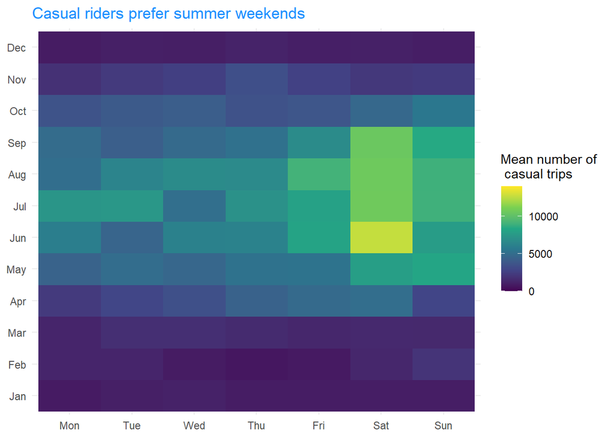

```r
daily_counts_w %>%
  group_by(month, month_abb, dow) %>%
  summarize(casual = sum(casual),
            n = n(),
            mean_casual = casual/ n) %>%    #View()
  ggplot(aes(dow, month_abb, fill = mean_casual)) +
  geom_raster() +
  scale_fill_viridis_c(limits = c(0, 14000)) +
  theme_minimal() +
  labs(fill = "Mean number of \n casual trips",
       title = "Casual riders prefer summer weekends",
       x = NULL, y = NULL) +
  theme(plot.title = element_text(color = "dodgerblue"))
```

Now we make the same type of heatmap for members. In contrast to casual riders, members take the most trips on weekdays.

Like casual riders, members take more trips from May - September and trips decline from November - March. However the dropoff in activity seems to be less drastic than we see with casual riders.

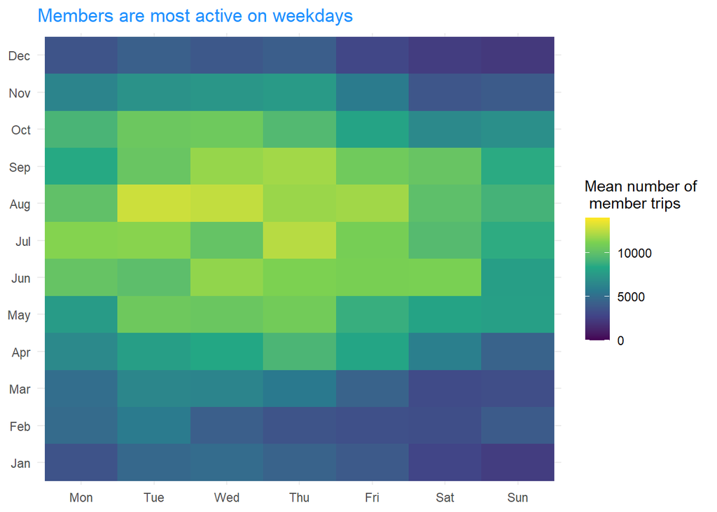

### Examining ridership by day and hour of day

Next, we want to understand if member and casual ridership differ by hour of the day. To do this, we will create barplots of mean trips by hour, faceted by day of the week.

To start, we need to create a data frame of hourly ridership counts, based on  
the time each trip started.

```r
hourly_counts <- bikes %>%
  group_by(month, month_abb, dow, hod, member_casual) %>%
  summarize(n  = n()) %>%
  mutate(hod_fct = factor(hod), .after = hod) %>%
  ungroup()

glimpse(hourly_counts)
```

```
## Rows: 4,032
## Columns: 7
## $ month         <dbl> 1, 1, 1, 1, 1, 1, 1, 1, 1, 1, 1, 1, 1, 1, 1, 1, 1, 1, 1,…
## $ month_abb     <ord> Jan, Jan, Jan, Jan, Jan, Jan, Jan, Jan, Jan, Jan, Jan, J…
## $ dow           <ord> Mon, Mon, Mon, Mon, Mon, Mon, Mon, Mon, Mon, Mon, Mon, M…
## $ hod           <dbl> 0, 0, 1, 1, 2, 2, 3, 3, 4, 4, 5, 5, 6, 6, 7, 7, 8, 8, 9,…
## $ hod_fct       <fct> 0, 0, 1, 1, 2, 2, 3, 3, 4, 4, 5, 5, 6, 6, 7, 7, 8, 8, 9,…
## $ member_casual <chr> "casual", "member", "casual", "member", "casual", "membe…
## $ n             <int> 60, 97, 29, 48, 24, 24, 6, 25, 23, 50, 47, 182, 94, 650,…
```

The code to plot casual trips is shown below. The code to plot member trips is almost identical.

Members and casual riders show different patterns of starting trips. Casual riders show more overall activity on weekends than weekdays. Weekend activity has a broad peak from the late morning to late afternoon. Weekday activity peaks around 5 pm.

Member activity is bimodal on weekdays. We see peaks around 7-8 am and again around 5 pm. This would be consistent with members using trips to commute to and from work or school. We also see that member activity is higher on weekdays than weekends.

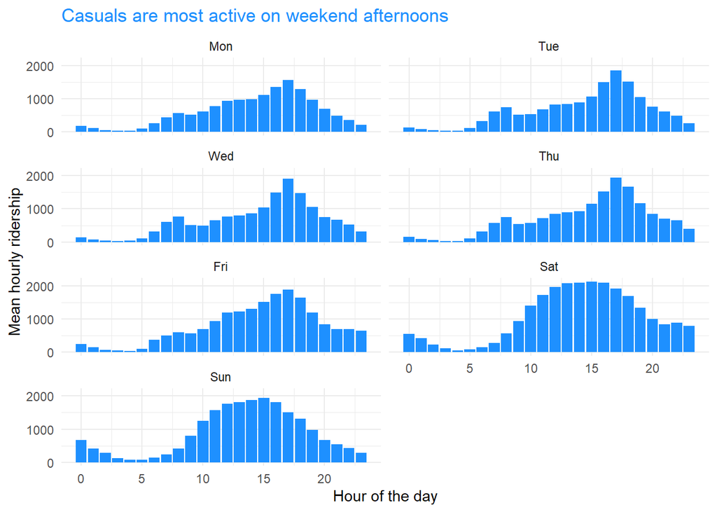

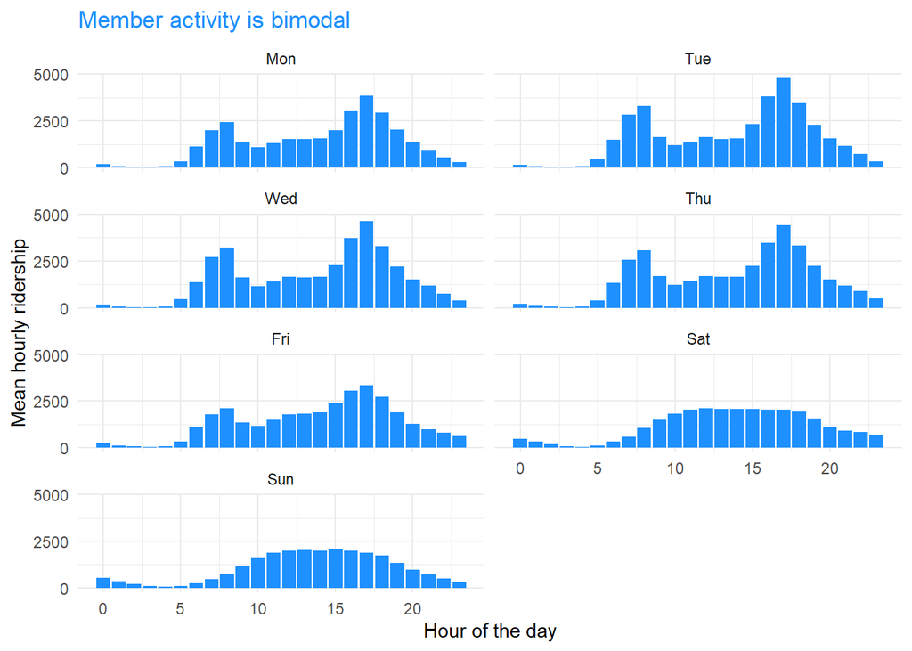

```r
hourly_counts %>%
  filter(member_casual == "casual") %>%
  ggplot(aes(hod, n)) +
  geom_bar(stat = "summary", fun = "mean", fill = "dodgerblue") +
  theme_minimal() +
  facet_wrap(~ dow, nrow = 4) +
  labs(title = "Casuals are most active on weekend afternoons",
       y = "Mean hourly ridership",
       x = "Hour of the day") +
  scale_y_continuous(n.breaks = 3) +
  theme(plot.title = element_text(color = "dodgerblue"))
```